# Linear models - Assignment 2

Dawid Wegner

25/10/2020

```r
library(ggplot2)
options(warn = -1)
set.seed(100)
```

# Task 1

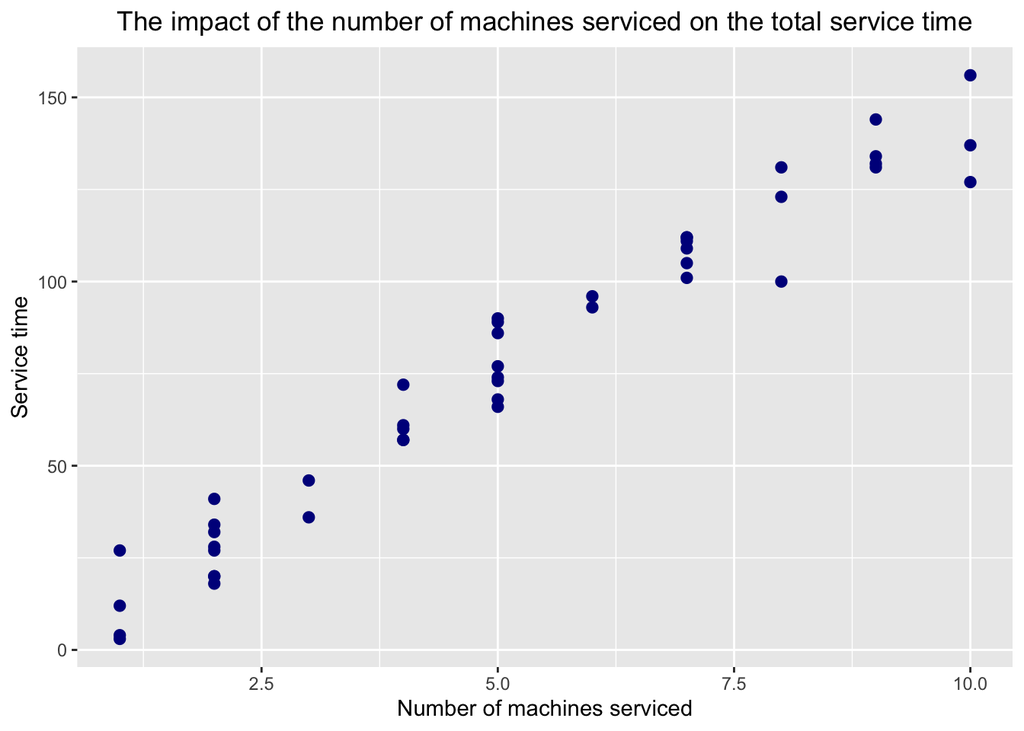

```r
copiers_df <- read.table('CH01PR20', col.names = c("service_time", "machines_count"))
ggplot(copiers_df) +
  geom_point(aes(x = machines_count, y = service_time), shape = 19, size = 2.2, color="darkblue") +
  xlab('Number of machines serviced') +
  ylab('Service time') +
  ggtitle("The impact of the number of machines serviced on the total service time") +
  theme(plot.title = element_text(hjust = 0.5))
```

The plot suggests that the relationship between the number of machines serviced and the service time is approximately linear. Additionally, the correlation between these two variables is positive. Note that this relation holds if the number of machines serviced is in the range [1, 10], but we cannot conclude that it holds for any value of the considered parameter.

# Task 2

```r
get_linear_model <- function (x_values, y_values) {
  linear_model <- data.frame(matrix(nrow = 1, ncol = 6))
  colnames(linear_model) <- c("beta0", "beta1", "beta0_se", "beta1_se", "slope_t_statistic", "slope_p_value")
  x_mean <- mean(x_values)
  y_mean <- mean(y_values)
  beta1 <- sum((x_values - x_mean) * (y_values - y_mean)) / sum((x_values - x_mean) ^ 2)
  beta0 <- y_mean - beta1 * x_mean
  errors <-  y_values - (beta0  + beta1 * x_values)
  errors_var <- sum(errors ^ 2) / (length(errors) - 2)
  print(errors_var)
  beta1_se <- sqrt(errors_var / sum((x_values - x_mean) ^ 2))
  beta0_se <- sqrt(errors_var * (1 / length(x_values) + x_mean ^ 2 / sum((x_values - x_mean) ^ 2)))
  slope_t_statistic <-  beta1 / beta1_se
  slope_p_value <- 2 * pt(abs(slope_t_statistic), df = length(x_values) - 2, lower.tail = FALSE)
  linear_model["beta0"] <- beta0
  linear_model["beta1"] <- beta1
  linear_model["beta0_se"] <- beta0_se
  linear_model["beta1_se"] <- beta1_se
  linear_model["slope_t_statistic"] <- slope_t_statistic
  linear_model["slope_p_value"] <- slope_p_value
  return(linear_model)
}

round(get_linear_model(copiers_df$machines_count, copiers_df$service_time), digits = 4)
```

```
[1] 79.45063
```

| beta0 | beta1 | beta0_se | beta1_se | slope_t_statistic | slope_p_value |
| --- | --- | --- | --- | --- | --- |
| -0.5802 | 15.0352 | 2.8039 | 0.4831 | 31.1233 | 0 |

Our problem is to find parameters $\hat{\beta_0}, \hat{\beta_1}$ of the equation $y = \hat{\beta_0} + \hat{\beta_1}x$, such that the expression $RSS = \sum_k (y^{real}_k - (\hat{\beta_0} + \hat{\beta_1}x_k))^2$ is minimized. It is known that the optimal parameters can be calculated using the equations $\hat{\beta_1} = \frac{\sum_k (x_k - \overline{x})(y_k - \overline{y})}{\sum_k (x_k - \overline{x})^2}$ and $\hat{\beta_0} = \overline{y} - \hat{\beta_1} \overline{x}$. These relations can be showed using some calculus. Additionally, treating $\hat{\beta_0}, \hat{\beta_1}$ as estimators, allows us to derive the formulas for standard errors: $SE(\hat{\beta_0})^2 = \sigma^2[\frac{1}{n} + \frac{\overline{x}^2}{\sum_k (x_k - \overline{x})^2)}]$ and $SE(\hat{\beta_1})^2 = \frac{\sigma^2}{\sum_k (x_k - \overline{x})^2}$, where $\sigma^2 = Var(y - (\hat{\beta_0} + \hat{\beta_1}x))$.

# Task 3

```r
fit_and_estimate_value <- function (x_values, y_values, estimation_x, significance_level = 0.05) {
  linear_model <- get_linear_model(x_values, y_values)
  beta0 <- linear_model$beta0
  beta1 <- linear_model$beta1
  estimation_y <- beta0 + beta1 * estimation_x
  values_count <- length(x_values)
  x_mean <- mean(x_values)
  errors <- y_values - (beta0 + beta1 * x_values)
  errors_var <- sum(errors ^ 2) / (length(errors) - 2)
  ssx <- sum((x_values - x_mean) ^ 2)
  standard_error <- sqrt(errors_var * (1 / values_count + ((estimation_x - x_mean) ^ 2) / ssx))
  confidence_interval_length <- qt(1 - significance_level / 2, values_count - 2) * standard_error
  min_interval <- estimation_y - confidence_interval_length
  max_interval <- estimation_y + confidence_interval_length
  return(data.frame(
    estimation_y=estimation_y, standard_error=standard_error, min_interval=min_interval, max_interval=max_interval
  ))
}

round(fit_and_estimate_value(copiers_df$machines_count, copiers_df$service_time, estimation_x = 11.0), digits = 4)
```

```
[1] 79.45063
```

| estimation_y | standard_error | min_interval | max_interval |
| --- | --- | --- | --- |
| 164.8076 | 3.1399 | 158.4754 | 171.1397 |

# Task 4

```r
fit_and_predict_value <- function (x_values, y_values, estimation_x, significance_level = 0.05) {
  linear_model <- get_linear_model(x_values, y_values)
  beta0 <- linear_model$beta0
  beta1 <- linear_model$beta1
  estimation_y <- beta0 + beta1 * estimation_x
  values_count <- length(x_values)
  x_mean <- mean(x_values)
  errors <- y_values - (beta0 + beta1 * x_values)
  errors_var <- sum(errors ^ 2) / (length(errors) - 2)
  ssx <- sum((x_values - x_mean) ^ 2)
  standard_error <- sqrt(errors_var * (1 + 1 / values_count + ((estimation_x - x_mean) ^ 2) / ssx))
  confidence_interval_length <- qt(1 - significance_level / 2, values_count - 2) * standard_error
  min_interval <- estimation_y - confidence_interval_length
  max_interval <- estimation_y + confidence_interval_length
  return(data.frame(
    estimation_y=estimation_y, standard_error=standard_error, min_interval=min_interval, max_interval=max_interval
  ))
}

round(fit_and_predict_value(copiers_df$machines_count, copiers_df$service_time, estimation_x = 11.0), digits = 4)
```

```
[1] 79.45063
```

| estimation_y | standard_error | min_interval | max_interval |
| --- | --- | --- | --- |
| 164.8076 | 9.4504 | 145.7491 | 183.866 |

# Task 5

```
[1] 79.45063
```

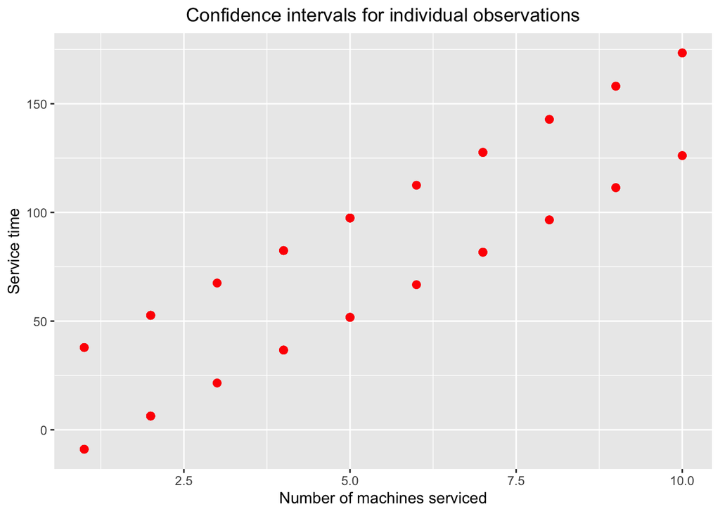

```r
plot_prediction_interval <- function (x_values, y_values, significance_level = 0.05) {
  linear_model <- get_linear_model(x_values, y_values)
  beta0 <- linear_model$beta0
  beta1 <- linear_model$beta1
  predicted_values <- beta0 + beta1 * x_values
  values_count <- length(x_values)
  x_mean <- mean(x_values)
  errors <- y_values - (beta0 + beta1 * x_values)
  errors_var <- sum(errors ^ 2) / (length(errors) - 2)
  ssx <- sum((x_values - x_mean) ^ 2)
  standard_errors <- sqrt(errors_var * (1 + 1 / values_count + ((x_values - x_mean) ^ 2) / ssx))
  fisher_constant <- sqrt(2 * qf(1 - significance_level, 2, values_count - 2))
  confidence_interval_lengths <- fisher_constant * standard_errors
  min_values <- predicted_values - confidence_interval_lengths
  max_values <- predicted_values + confidence_interval_lengths
  data_df <- data.frame(x_value = x_values, min_value = min_values, max_value = max_values)
  ggplot(data_df) +
    geom_point(aes(x = x_value, y = min_value), shape = 19, size = 2.2, color = "red") +
    geom_point(aes(x = x_value, y = max_value), shape = 19, size = 2.2, color = "red") +
    xlab('Number of machines serviced') +
    ylab('Service time') +
    ggtitle("Confidence intervals for individual observations") +
    theme(plot.title = element_text(hjust = 0.5))
}

plot_prediction_interval(copiers_df$machines_count, copiers_df$service_time)
```

The $95\%$ prediction intervals of multiple values can be calculated using the Fisher distribution with the parameters $df_1 = 2$ and $df_2 = n - 2$. The other quantities like the standard errors are computed in the same way as in the task of predicting one value. After applying this theory, the graph of $95\%$ confidence intervals was plotted. The first observation from the plot is that the lengths of the prediction intervals are quite high compared to the lengths of the estimation intervals. The other observation is that the lowest lengths of intervals are achieved near the mean of the number of machines serviced. It is a direct result of the formula for calculating the standard error that takes into account the deviation from the mean of observations.

# Task 6

```r
calculate_test_power <- function(elements_count, error_var, ssx, beta_value, significance_level = 0.05) {
  beta1_sd <- error_var / ssx
  t_mean <- beta_value / sqrt(beta1_sd)
  quantile <- qt(1 - significance_level / 2, df = elements_count - 2)
  lower_pbb <- pt(-quantile, df = elements_count - 2, ncp = t_mean)
  upper_pbb <- pt(quantile, df = elements_count - 2, ncp = t_mean)
  return (1 - upper_pbb + lower_pbb)
}

calculate_test_power(elements_count = 40, error_var = 120, ssx = 1000, beta_value = 1.0)
```

```
[1] 0.8032105
```

The power of rejecting the null hypothesis, stating that the regression slope is $0$, is equal to approximately $0.8$. It means that assuming that the true value of the slope is equal to 1.0, the probability of rejecting the null hypothesis is equal to $80\%$. It’s not surprising as only $40$ samples were used to fit the regression line and the variance of the error is quite high compared to the variance of X variable that is equal to $\frac{1000}{40} = 25$.

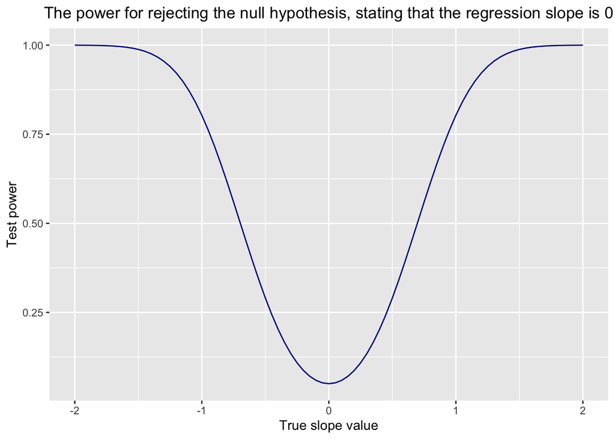

```r
beta_values <- seq(from = -2, to = 2, by = 0.05)
test_powers <- c()
for (index in seq_along(beta_values)) {
  power <- calculate_test_power(elements_count = 40, error_var = 120, ssx = 1000, beta_value = beta_values[index])
  test_powers[[index]] <- power
}
powers_df <- data.frame(beta_value = beta_values, test_power = test_powers)
ggplot(powers_df) +
  geom_line(aes(x = beta_value, y = test_power), color="darkblue") +
  xlab('True slope value') +
  ylab('Test power') +
  ggtitle("The power for rejecting the null hypothesis, stating that the regression slope is 0") +
  theme(plot.title = element_text(hjust = 0.5))
```

# Task 7

```r
test_sample_rejection_frequency <- function (
  x_generator, error_generator, beta, experiments_count = 1000, samples_per_experiment = 200, significance_level = 0.05
) {
  x_samples <- x_generator(samples_count = samples_per_experiment)
  x_mean <- mean(x_samples)
  rejections <- 0
  for (i in 1:experiments_count) {
    error_samples <- error_generator(samples_count = samples_per_experiment)
    y_samples <- 5 + beta * x_samples + error_samples
    y_mean <- mean(y_samples)
    beta1_estimator <- sum((x_samples - x_mean) * (y_samples - y_mean)) / sum((x_samples - x_mean) ^ 2)
    beta0_estimator <- y_mean - beta1_estimator * x_mean
    errors <- y_samples - (beta0_estimator + beta1_estimator * x_samples)
    errors_var <- sum(errors ^ 2) / (length(errors) - 2)
    standard_error <- sqrt(errors_var / sum((x_samples - x_mean) ^ 2))
    test_statistic <- beta1_estimator / standard_error
    is_rejected <- abs(test_statistic) >= qt(1 - significance_level / 2, samples_per_experiment - 2)
    if (is_rejected) {
      rejections <- rejections + 1
    }
  }
  return(rejections / experiments_count)
}

x_generator <- function (samples_count) rnorm(samples_count, mean = 0, sd = 5e-3)
error_generator1 <- function (samples_count) rnorm(samples_count, mean = 0, sd = 1.0)
error_generator2 <- function (samples_count) rexp(samples_count, rate = 1.0)
```

```r
test_sample_rejection_frequency(x_generator, error_generator1, beta = 0)
```

```
[1] 0.047
```

```r
test_sample_rejection_frequency(x_generator, error_generator2, beta = 0)
```

```
[1] 0.045
```

```r
test_sample_rejection_frequency(x_generator, error_generator1, beta = 1.5)
```

```
[1] 0.054
```

```r
test_sample_rejection_frequency(x_generator, error_generator2, beta = 1.5)
```

```
[1] 0.062
```

The results show that the probability of rejecting the null hypothesis is approximately equal to the level of significance $\alpha = 0.05$ in all of the conducted experiments. In the experiment $a$ this result was quite expected as the null hypothesis is true in this case and the errors come from the normal distribution. The similar result was obtained in the experiment $b$, showing that changing the distribution of errors doesn’t change the results drastically. The obtained rejection probability is a bit further from the level of significance compared to the experiment $a$, suggesting that there is some impact caused by changing the distribution of errors.

The results of experiments $c$ and $d$ were less expected from the theoretical point of view as the true slope is set to $1.5$ in these cases. But after analysing it deeper, it is quite obvious that the fitted line should be close to the lines fitted in the previous experiments. The reason is that the variables $X$ are dominated by the errors that have much higher variance. It implies that the enumerator in the standard error equation is quite high, while the denominator is close to $0$. As a result, the standard error is high and the test statistic is low. Taking it into account, the obtained results are expected.

# Task 8

```r
round(qt(0.975, df = 8), digits = 3)
```

```
[1] 2.306
```

```r
round(2 * pt(3.0, df = 8, lower.tail = FALSE), digits = 3)
```

```
[1] 0.017
```

The t-statistic is equal to $\frac{\hat{\beta_1} - 0.0}{s(\beta_1)} = \frac{3.0}{1.0} = 3.0$. This means that assuming the significance level of $\alpha = 0.05$, we can reject the null hypothesis as the p-value is equal to $0.017$. This gives us a statistical evidence that there is some relation between $X$ and $Y$.

Given the $95\%$ confidence interval when $x = 5$, it’s possible to derive the standard error of the estimation. As $t_c * s(\hat{\beta_1}) = 3.0$ and $t_c = 2.306$, it holds $s(\hat{\beta_1}) = \frac{3.0}{2.306} \approx 1.3$. The standard error of the prediction $s_p(\hat{\beta_1})$ can be calculated using the fact that $s_p^2(\hat{\beta_1}) = s^2(\hat{\beta_1}) + s^2$. From this equation it follows that $s_p(\hat{\beta_1}) = \sqrt{1.3 * 1.3 + 4 * 4} \approx 4.2$. As a consequence, the prediction interval is equal to $[13 - 2.306 * 4.2, 13 + 2.306 * 4.2] \approx [3.3148, 22.6852]$.